# Projet de Web scraping: envoi automatisé des invitations personnalisées aux blogueurs de Jazz

Barthel Valentin et Coroama Georgiana-Ioana

2024-04-02

```r
knitr::opts_chunk$set(error = TRUE)
```

## Etapes de notre projet

- Web scrapping des 2 sites
- Création des adresses mail fictives pour les blogueurs et envoi du mail automatique personnalisé
- Création d’un script final avec des fonctions par partie (get_bloggers, get_festivals et send_jazz_invitations) et une fonction globale (get_everything) qui appelle ces fonctions pour executer l’intégralité du code.

## 1. Scraping du site des festivals: fonction qui récupère l’ensemble des urls des pages à scraper( get_all_pages())

https://www.smoothjazz.com/festivals

```python
def get_all_pages():
    urls = []
    page_number = 0
    for i in range(1, 16):
        url = f"https://www.smoothjazz.com/festivals?page={page_number}"
        page_number += 1
        urls.append(url)
    return urls
```

## Fonction permettant de scraper le nom, la ville, la région, le pays et la date des festivals de chaque page (get_event_names(url))

```python
def get_event_names(url):
    r = requests.get(url)
    soup = BeautifulSoup(r.content, features="html.parser")
    festivals = soup.find_all("tr")
    data = []
    for festival in festivals[1:]:
        event_details = {}
        event_details['Nom_Event'] = festival.find("td", headers="view-title-table-column", class_="views-field views-field-title is-active").text.strip() if festival.find("td", headers="view-title-table-column", class_="views-field views-field-title is-active") else ""
        event_details['Ville_Envent'] = festival.find("td", headers="view-field-city-table-column", class_="views-field views-field-field-city").text.strip() if festival.find("td", headers="view-field-city-table-column", class_="views-field views-field-field-city") else ""
        event_details['Region_Event'] = festival.find("td", headers="view-field-state-region-table-column", class_="views-field views-field-field-state-region").text.strip() if festival.find("td", headers="view-field-state-region-table-column", class_="views-field views-field-field-state-region") else ""
        event_details['Pays_Event'] = festival.find("td", headers="view-field-country-table-column", class_="views-field views-field-field-country").text.strip() if festival.find("td", headers="view-field-country-table-column", class_="views-field views-field-field-country") else ""
        event_details['Periode_Event'] = festival.find("td", headers="view-field-event-month-table-column", class_="views-field views-field-field-event-month").text.strip() if festival.find("td", headers="view-field-event-month-table-column", class_="views-field views-field-field-event-month") else ""
        data.append(event_details)
    return data
```

```python
get_event_names(url)
```

```
## [{'Nom_Event': 'Eagle jazz Festival', 'Ville_Envent': 'Boise', 'Region_Event': 'Eagle, Idaho', 'Pays_Event': 'USA', 'Periode_Event': 'SEP'}, {'Nom_Event': '2023 VrroomVIP JAZZ Experience', 'Ville_Envent': 'Durham', 'Region_Event': 'North Carolina', 'Pays_Event': 'USA', 'Periode_Event': 'OCT'}, {'…
```

## Fonction qui permet de mettre sous la forme d’une data frame tous les informations récupérées par get_event_names()

```python
def scrape_all_events():
    urls = get_all_pages()
    all_events = []
    for url in urls:
        events = get_event_names(url)
        all_events.extend(events)
    return pd.DataFrame(all_events)
```

```python
TableEvent = scrape_all_events()

TableEvent["Pays_Event"] = TableEvent["Pays_Event"].replace({"United States": "USA"})
TableEvent
```

```
##                                          Nom_Event  ... Periode_Event
## 0                              Eagle jazz Festival  ...           SEP
## 1                   2023 VrroomVIP JAZZ Experience  ...           OCT
## 2    21st Smooth Jazz for Scholars Benefit Concert  ...           APR
## 3              67th Monterey Jazz Festival (MJF67)  ...           SEP
## 4                     A Celebration Of Black Music  ...           JUN
## ..                                             ...  ...           ...
## 367                   Wine, Art, and Jazz Festival  ...           AUG
## 368           Winnipeg International Jazz Festival  ...
## 369                       Winterpark Jazz Festival  ...           JUL
## 370                    Woodson-Young Jazz Festival  ...           JUN
## 371                            Yosemite Jazz Train  ...  Periodically
##
## [372 rows x 5 columns]
```

## 2. Scraping du site des blogueurs: fonction permettant de récupérer les url

```python
def get_url(url):
    user_agents_list = [
        'Mozilla/5.0 (iPad; CPU OS 12_2 like Mac OS X) AppleWebKit/605.1.15 (KHTML, like Gecko) Mobile/15E148',
        'Mozilla/5.0 (Macintosh; Intel Mac OS X 10_15_7) AppleWebKit/537.36 (KHTML, like Gecko) Chrome/99.0.4844.83 Safari/537.36',
        'Mozilla/5.0 (Windows NT 10.0; Win64; x64) AppleWebKit/537.36 (KHTML, like Gecko) Chrome/99.0.4844.51 Safari/537.36'
    ]#Liste des agents simulés

    headers = {'User-Agent': random.choice(user_agents_list)}
    with requests.Session() as session:
        try:
            response = session.get(url, headers=headers)
            response.raise_for_status()  # Cela va lever une exception pour les codes 4xx/5xx
            return BeautifulSoup(response.text, features="html.parser")
        except requests.RequestException as e:
            print(f"Error retrieving URL {url}: {e}")
            return None
```

## Fonction permettant de récupérer les noms des blogueurs

```python
def get_names(url):
    soup = get_url(url)
    h3s = soup.find_all('h3', attrs={'class':'feed_heading'})

    noms = []

    for h3 in h3s:
        nns = h3.find_all('a', class_='tlink fd_lk')

        if len(nns) > 0:
            # Accès direct au texte de chaque élément span trouvé
            for nn in nns:
                noms.append(nn.get_text())
        else:
            noms.append('none')
    return noms

nom_blog = get_names("https://music.feedspot.com/jazz_blogs/")
print(len(nom_blog))
```

```
## 75
```

```python
print(nom_blog)
```

```
## ['Free Jazz', 'Jazz&Blues', 'A Jazz Noise', 'Yoko Miwa ', 'LondonJazz', 'New York Jazz Workshop Blog', 'JazzWax', 'Tracce di Jazz', 'Pitchfork » Jazz', 'Library of Congress » Jazz ', 'All About Jazz', 'WartaJazz.com', 'Jazzwise', 'Ottawa Citizen » Jazz Blog ', 'Jazz Journal', 'The Jazz Mann', 'Wy…
```

## Fonction qui génère l’adresse mail de chaque blogueur à partir du nom de son blog

```python
def create_email():
    adresses_email = []
    for blog in nom_blog:
    # Nettoyer et remplacer les espaces et caractères spéciaux
        nom_simplifie = blog.strip().replace(' ', '_').replace('&', 'and').replace('»', '').replace('|', '').replace('.', '').lower()
    # Ajouter un domaine fictif
        adresse_email = nom_simplifie + "@exemple.com"
        adresses_email.append(adresse_email)

# Afficher les adresses e-mail créées
    for adresse in adresses_email:
        return adresses_email
create_email()
```

```
## ['free_jazz@exemple.com', 'jazzandblues@exemple.com', 'a_jazz_noise@exemple.com', 'yoko_miwa@exemple.com', 'londonjazz@exemple.com', 'new_york_jazz_workshop_blog@exemple.com', 'jazzwax@exemple.com', 'tracce_di_jazz@exemple.com', 'pitchfork__jazz@exemple.com', 'library_of_congress__jazz@exemple.co…
```

## Fonction qui permet de récupérer la localisation des blogueurs (ville, région, pays)

```python
def get_locals(url):
    soup = get_url(url)
    h3s = soup.find_all('p', attrs={'class':'trow trow-wrap'})

    locals_ = []

    for h3 in h3s:
        nns = h3.find_all('span', class_='location_new')

        if len(nns) > 0:
            # Accès direct au texte de chaque élément span trouvé
            for nn in nns:
                locals_.append(nn.get_text())
        else:
            locals_.append('none')
    return locals_

localisation = get_locals("https://music.feedspot.com/jazz_blogs/")
print(len(localisation))
```

```
## 75
```

```python
print(localisation)
```

```
## ['US', 'Paris, Ile-de-France, France', 'Barcelona, Catalunya, Spain', 'Boston, Massachusetts, US', 'London, England, UK', 'New York, US', 'US', 'Italy', 'US', 'Washington, District of Columbia, US', 'Philadelphia, Pennsylvania, US', 'Yogyakarta, Indonesia', 'London, England, UK', 'none', 'London,…
```

```python
Ville = []
Region = []
Pays = []

#Boucle permettant d'isoler la ville, la région et le pays de la variable 'localisation'
for loc in localisation:
    parts = loc.split(', ')

    # Gestion des cas spéciaux
    if loc == 'none' or len(parts) == 1:
        Ville.append('none')
        Region.append('none')
        Pays.append(parts[0] if loc != 'none' else 'none')
    elif len(parts) == 2:
        # Supposition: format "Ville, Pays"
        Ville.append(parts[0])
        Region.append('none')
        Pays.append(parts[1])
    elif len(parts) >= 3:
        # Format complet "Ville, Région, Pays"
        Ville.append(parts[0])
        Region.append(parts[1])
        Pays.append(parts[2])

print("Villes:", Ville)
```

```
## Villes: ['none', 'Paris', 'Barcelona', 'Boston', 'London', 'New York', 'none', 'none', 'none', 'Washington', 'Philadelphia', 'Yogyakarta', 'London', 'none', 'London', 'none', 'New York', 'Ottawa', 'Florida', 'Hengelo', 'none', 'New York', 'San Francisco', 'Harlem', 'Florida', 'Washington', 'none'…
```

```python
print("Regions:", Region)
```

```
## Regions: ['none', 'Ile-de-France', 'Catalunya', 'Massachusetts', 'England', 'none', 'none', 'none', 'none', 'District of Columbia', 'Pennsylvania', 'none', 'England', 'none', 'England', 'none', 'none', 'Ontario', 'none', 'Overijssel', 'none', 'none', 'California', 'New York', 'none', 'District of…
```

```python
print("Pays:", Pays)
```

```
## Pays: ['US', 'France', 'Spain', 'US', 'UK', 'US', 'US', 'Italy', 'US', 'US', 'US', 'Indonesia', 'UK', 'none', 'UK', 'UK ', 'US', 'Canada', 'US', 'Netherlands', 'none', 'US', 'US', 'US', 'US', 'US', 'US', 'none', 'none', 'UK', 'US', 'Canada', 'Poland ', 'none', 'UK', 'US', 'US', 'UK', 'US', 'US', …
```

## Fonction pour obtenir la page web de chaque blogueur

```python
def get_webs(url):
    soup = get_url(url)
    h3s = soup.find_all('p', attrs={'class':'trow trow-wrap'})

    webs = []

    for h3 in h3s:
        nns = h3.find_all('a', class_='ext')

        if len(nns) > 0:
            for nn in nns:
                webs.append(nn.get_text())
        else:
            webs.append('none')
    return webs
site_web = get_webs("https://music.feedspot.com/jazz_blogs/")
print(len(site_web))
```

```
## 75
```

```python
print(site_web)
```

```
## ['freejazzblog.org', 'youtube.com/cha..', 'ajazznoise.com', 'yokomiwa.com/blog', 'londonjazznews.com', 'newyorkjazzworksho..', 'jazzwax.com', 'traccedijazz.com', 'pitchfork.com/news..', 'blogs.loc.gov/musi..', 'allaboutjazz.com/a..', 'wartajazz.com', 'jazzwise.com/news', 'ottawacitizen.com/..', '…
```

## Fonction pour obtenir le nombre de followers pour chaque réseau (s’il y en a )

```python
def get_followers(url, name_class):

    soup = get_url(url)
    spans = soup.find_all('span', attrs={'class':'eng-outer-wrapper eng-outer-wrapper eng-outer-nodot eng-outer-wrapper--free'})

    abo = []

    for span in spans:

        imgs = span.find_all('span', class_=f'{name_class}')

        if len(imgs) > 0:
            lst = [img.find_all("span", class_='eng_v') for img in imgs]
            abo.append(lst[0][0].get_text())
        else : abo.append('none')

    return abo

twitsub = get_followers("https://music.feedspot.com/jazz_blogs/", "fs-twitter")
fbsub = get_followers("https://music.feedspot.com/jazz_blogs/", "fs-facebook")
instasub = get_followers("https://music.feedspot.com/jazz_blogs/", "fs-instagram")

print(twitsub)
```

```
## ['3.9K', '765', '1.5K', '1.3K', '51.5K', '1.6K', '11.7K', '229', '3.2M', '1.2M', '92.6K', '19.5K', '56.3K', '249.6K', '11.3K', '4.9K', '135.8K', '18.1K', '11.9K', '31.8K', '1.3K', '434', '28.1K', '14.9K', '34', '3.5K', '624', 'none', 'none', 'none', 'none', '12.2K', 'none', '5.9K', '25.4K', '1.6K…
```

```python
print(fbsub)
```

```
## ['1.6K', '123.7K', '2K', '3.5K', '7.8K', '16K', 'none', '6.4K', '1.4M', '497.4K', '129.1K', '4.8K', '21.6K', '194.7K', '1.9K', 'none', '785.3K', '12.8K', 'none', '11.4K', 'none', 'none', '85.5K', '54.6K', '7.4K', '3.3K', 'none', 'none', 'none', 'none', '115', '10.7K', 'none', '5.2K', '7.9K', 'non…
```

```python
print(instasub)
```

```
## ['none', 'none', 'none', '2.4K', 'none', 'none', 'none', 'none', '1.5M', 'none', '4.1K', '10.4K', '11K', '51.2K', 'none', 'none', '324.5K', '6.8K', 'none', '4.9K', 'none', 'none', '108.8K', '17.3K', '3.7K', '3.1K', 'none', 'none', 'none', 'none', '262', '5.8K', 'none', '1.5K', 'none', 'none', '16…
```

## Fonction pour convertir le nombre d’abonnées sous format string en integer en remplaçant les “k” et “M” avec le bon nombre de “0”

```python
def convertir_en_nombre(abonnes_str):
    # Gère le cas spécial où la chaîne est 'none'
    if abonnes_str == 'none':
        return 0  # Retourne 0 ou une autre valeur par défaut appropriée
    # Supprime 'K', multiplie par 1000 si 'K' était présent
    if 'K' in abonnes_str:
        return int(float(abonnes_str.replace('K', '')) * 1000)
    # Ajoute une condition pour gérer les cas où 'M' est présent
    elif 'M' in abonnes_str:
        return int(float(abonnes_str.replace('M', '')) * 1000000)
    # Supprime les points et les virgules avant de convertir en int
    return int(abonnes_str.replace('.', '').replace(',', ''))
```

```python
# Application de la fonction à tous les éléments des listes
fbsub_num = [convertir_en_nombre(abonne) for abonne in fbsub]
twitsub_num = [convertir_en_nombre(abonne) for abonne in twitsub]
instasub_num = [convertir_en_nombre(abonne) for abonne in instasub]
print(instasub_num)
```

```
## [0, 0, 0, 2400, 0, 0, 0, 0, 1500000, 0, 4100, 10400, 11000, 51200, 0, 0, 324500, 6800, 0, 4900, 0, 0, 108800, 17300, 3700, 3100, 0, 0, 0, 0, 262, 5800, 0, 1500, 0, 0, 16400, 0, 0, 8000, 0, 685, 0, 2400, 111600, 921, 3900, 0, 0, 0, 312, 0, 0, 0, 2100, 3400, 0, 0, 1200, 0, 7000, 48400, 0, 0, 0, 0, …
```

```python
print(fbsub_num)
```

```
## [1600, 123700, 2000, 3500, 7800, 16000, 0, 6400, 1400000, 497400, 129100, 4800, 21600, 194700, 1900, 0, 785300, 12800, 0, 11400, 0, 0, 85500, 54600, 7400, 3300, 0, 0, 0, 0, 115, 10700, 0, 5200, 7900, 0, 28600, 0, 578, 20000, 15, 0, 0, 5300, 43000, 997, 6600, 0, 3600, 1400, 58100, 0, 772, 0, 2100,…
```

```python
print(twitsub_num )
```

```
## [3900, 765, 1500, 1300, 51500, 1600, 11700, 229, 3200000, 1200000, 92600, 19500, 56300, 249600, 11300, 4900, 135800, 18100, 11900, 31800, 1300, 434, 28100, 14900, 34, 3500, 624, 0, 0, 0, 0, 12200, 0, 5900, 25400, 1600, 1300, 25800, 2100, 4100, 2300, 373, 7000, 164, 914, 939, 2100, 1400, 375, 0, 7…
```

##Création de la table “DataBlog” avec l’ensemble des variables scrapées

```python
DataBlog = {"Nom Blog": nom_blog,
                "Pays": Pays,
                "Région": Region,
                "Ville": Ville,
                "Adresse Email": create_email(),
                "Site web": site_web,
                "Abonnées Facebook": fbsub_num,
                "Abonnées Twitter": twitsub_num,
                "Abonnées Instagram": instasub_num
                }

TableBlog = pd.DataFrame(DataBlog)

#La variable Pays pouvant prendre comme valeurs US et USA, nous nous accorderons à n'avoir qu'un output pour les deux cas (USA)
TableBlog["Pays"] = TableBlog["Pays"].replace({"US": "USA"})
TableBlog
```

```
##                       Nom Blog  ... Abonnées Instagram
## 0                    Free Jazz  ...                  0
## 1                   Jazz&Blues  ...                  0
## 2                 A Jazz Noise  ...                  0
## 3                   Yoko Miwa   ...               2400
## 4                   LondonJazz  ...                  0
## ..                         ...  ...                ...
## 70             Jazz from Geoff  ...                  0
## 71             JazzLocal32.com  ...                  0
## 72                Best of Jazz  ...                  0
## 73  Hartford Jazz Society Blog  ...                  0
## 74     Splash Point Music Blog  ...                619
##
## [75 rows x 9 columns]
```

```python
#Création du CSV 'TableBlog' qui sera stocké dans le folder contenant l'ensemble des scripts
nom_fichier = 'TableBlog.csv'
TableBlog.to_csv(nom_fichier, index=False)
```

## 3:Création du mail automatique: fonction qui génère le sujet et une partie du contenu personnalisé du mail pour chaque bloguer

```python
def format_blogger_email(blog_name, followers, country):
    email_subject = f"Invitation to Jazz Events in {country}"
    email_body = f"Dear {blog_name},\n\nIt's time for some good jazz! With more than {followers} jazz lovers following you, it seems like your community is growing by each day.\n\nThat's why we thought you might be interested in the jazz festivals taking place in your area soon.\n\n Check out all the festivals organized in {country}:"
    return email_subject, email_body
```

# Fonction qui génère la liste personnalisée des festivals pour chaque blogueur (en fonction de son pays d’origine)

```python
def format_event_list(events):
    event_list = []
    for _, event in events.iterrows():
        event_info = f"{event['Nom_Event']}"
        if not pd.isnull(event['Ville_Envent']) and not pd.isnull(event['Periode_Event']):
            event_info += f" ({event['Ville_Envent']} - {event['Periode_Event']})"
        elif not pd.isnull(event['Ville_Envent']):
            event_info += f" ({event['Ville_Envent']})"
        elif not pd.isnull(event['Periode_Event']):
            event_info += f" ({event['Periode_Event']})"
        event_list.append(event_info)

    formatted_list = "- " + "\n- ".join(event_list)
    return formatted_list
```

## Connexion au serveur SMTP et création de la fonction pour envoyer les mails automatiquement en incluant les 2 fonctions créées

```python
def send_jazz_event_invitations(smtp_server, smtp_port, smtp_username, smtp_password, TableBlog, TableEvent):
    #Gestion des erreurs à la connection au serveur de la boîte mail choisie
    try:
        server = smtplib.SMTP_SSL(smtp_server, smtp_port)
        server.login(smtp_username, smtp_password)
        print("Connexion au serveur SMTP réussie.")
    except Exception as e:
        print(f"Erreur de connexion au serveur SMTP: {e}")
        return
    #Initiation de la boucle pour créer un message personnalisé en fonction du blogueur, de son nombre d'abonnées
    # et de sa localisation
    for country in TableBlog['Pays'].unique():
        country_events = TableEvent[TableEvent['Pays_Event'].str.contains(country, case=False, na=False)]
        if not country_events.empty:
            country_blogs = TableBlog[TableBlog['Pays'] == country]
            for _, blog in country_blogs.iterrows():
                # Déterminer le nombre d'abonnés Facebook ou Twitter
                facebook_followers = blog['Abonnées Facebook']
                twitter_followers = blog['Abonnées Twitter']
                followers = facebook_followers if facebook_followers > 0 else twitter_followers

            # Utilisation de la fonction format_blogger_email pour formater le texte de l'email
                email_subject, email_body = format_blogger_email(blog['Nom Blog'], followers, country)

            # Construction de la liste des événements avec des informations supplémentaires
                formatted_event_list = format_event_list(country_events)
                email_body += f"\n\n{formatted_event_list}"

            # Ajout du reste du texte de l'email
                if len(country_events) > 1:
                    email_body += "\n\nAnd that's not all. As we appreciate your effort to spread the jazzy vibes across your passionate community, we'd love to offer you a free full access ticket to your favorite festival from the list.\n\n Find the full list of the festivals taking place all around the world at the following address: https://www.smoothjazz.com/festivals \n\nFeel free to write us back for more details.\n\nBest regards,\n The Jazzy World Team "
                else:
                    email_body += "\n\nAnd that's not all. As we appreciate your effort to spread the jazzy vibes across your passionate community, we'd love to offer you a free full access ticket to this festival.\n\n Find the full list of the festivals taking place all around the world at the following address: https://www.smoothjazz.com/festivals \n\n\nFeel free to write us back for more details.\n\nBest regards,\n The Jazzy World Team  "

                msg = MIMEMultipart()
                msg['From'] = smtp_username
                msg['To'] = blog['Adresse Email']
                msg['Subject'] = email_subject
                msg.attach(MIMEText(email_body, 'plain'))
                #Gestion des erreurs dans le cadre de l'envoie des mails
                try:
                    server.sendmail(smtp_username, blog['Adresse Email'], msg.as_string())
                    print(f"Email sent to {blog['Adresse Email']}")
                except Exception as e:
                    print(f"Failed to send email to {blog['Adresse Email']}: {e}")
    #Gestion des erreurs dans le cadre de la fermeture du serveur
    try:
        server.quit()
        print("Connexion SMTP fermée.")
    except Exception as e:
        print(f"Erreur lors de la fermeture de la connexion SMTP: {e}")
```

## Appel de la fonction pour l’envoie de mail

```python
send_jazz_event_invitations("smtp.gmail.com", 465, "jazzyworld67@gmail.com", "ogunqrpjhigzwpfc", TableBlog, TableEvent)
```

```
## Connexion au serveur SMTP réussie.
## Email sent to free_jazz@exemple.com
## Email sent to yoko_miwa@exemple.com
## Email sent to new_york_jazz_workshop_blog@exemple.com
## Email sent to jazzwax@exemple.com
## Email sent to pitchfork__jazz@exemple.com
## Email sent to library_of_congress__jazz@exemple.com
## Email sent to all_about_jazz@exemple.com
## Email sent to wynton_marsalis@exemple.com
## Email sent to jazz_chill_music@exemple.com
## Email sent to jazz_lives_blog@exemple.com
## Email sent to sfjazz@exemple.com
## Email sent to new_york_amsterdam__jazz_notes@exemple.com
## Email sent to jazz_blues_florida@exemple.com
## Email sent to capitalbop@exemple.com
## Email sent to bebop_spoken_here@exemple.com
## Email sent to thejazzworld@exemple.com
## Email sent to open_sky_jazz@exemple.com
## Email sent to learn_jazz_standards@exemple.com
## Email sent to debbie_burke@exemple.com
## Email sent to jazz_aspen_snowmass@exemple.com
## Email sent to wzum_jazz_pittsburgh@exemple.com
## Email sent to jazz_journalists_association@exemple.com
## Email sent to jazz24@exemple.com
## Email sent to all_that_philly_jazz@exemple.com
## Email sent to free_jazz_lessons_blog@exemple.com
## Email sent to jazztrail_blog@exemple.com
## Email sent to somehowjazz@exemple.com
## Email sent to jazzarts_charlotte_blog@exemple.com
## Email sent to gapplegate_music_review@exemple.com
## Email sent to ellington_reflections@exemple.com
## Email sent to brilliant_corners@exemple.com
## Email sent to neon_jazz@exemple.com
## Email sent to jazz__the_music_of_unemployment@exemple.com
## Email sent to hartford_jazz_society_blog@exemple.com
## Email sent to jazzandblues@exemple.com
## Email sent to jazz_guitar_licks_blog@exemple.com
## Email sent to a_jazz_noise@exemple.com
## Email sent to londonjazz@exemple.com
## Email sent to jazzwise@exemple.com
## Email sent to jazz_journal@exemple.com
## Email sent to uk_vibe@exemple.com
## Email sent to vortex_jazz_club@exemple.com
## Email sent to the_blue_moment__jazz@exemple.com
## Email sent to simplyjazztalk_blog@exemple.com
## Email sent to lancaster_jazz_blog@exemple.com
## Email sent to jazz_from_geoff@exemple.com
## Email sent to splash_point_music_blog@exemple.com
## Email sent to tracce_di_jazz@exemple.com
## Email sent to wartajazzcom@exemple.com
## Email sent to td_ottawa_jazz_festival@exemple.com
## Email sent to coastal_jazz_and_blues_society_blog@exemple.com
## Email sent to four_on_the_floor@exemple.com
## Email sent to decidedly_jazz_danceworks@exemple.com
## Email sent to jazz_in_europe@exemple.com
## Email sent to stringspace_blog@exemple.com
## Email sent to ausjazz_blog@exemple.com
## Email sent to jazz_workshop_australia@exemple.com
## Email sent to tokyo_jazz_site_blog@exemple.com
## Email sent to clean_feed_records@exemple.com
## Connexion SMTP fermée.
```

## Exemples:

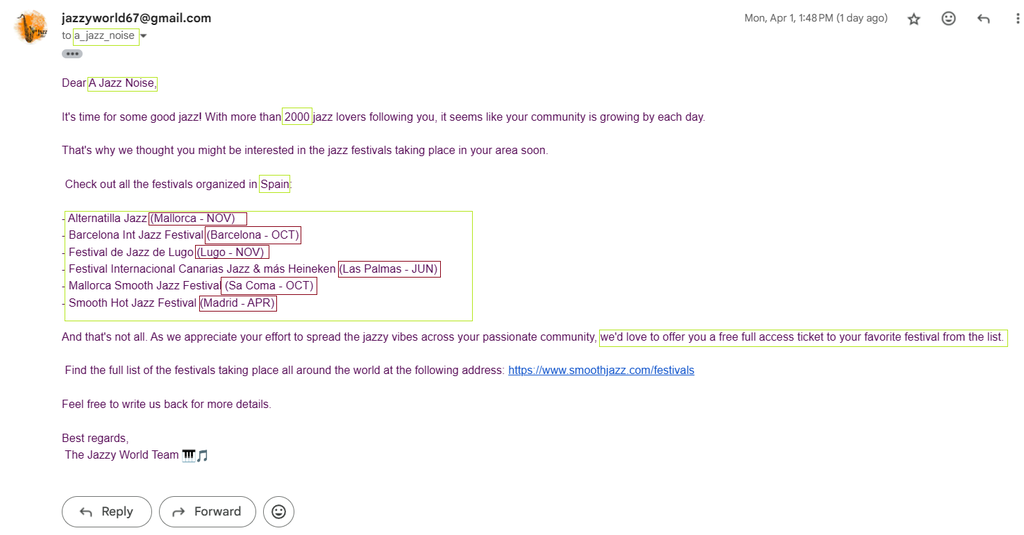

[figure not shown]

## Envoi à nos propres adresses mail:

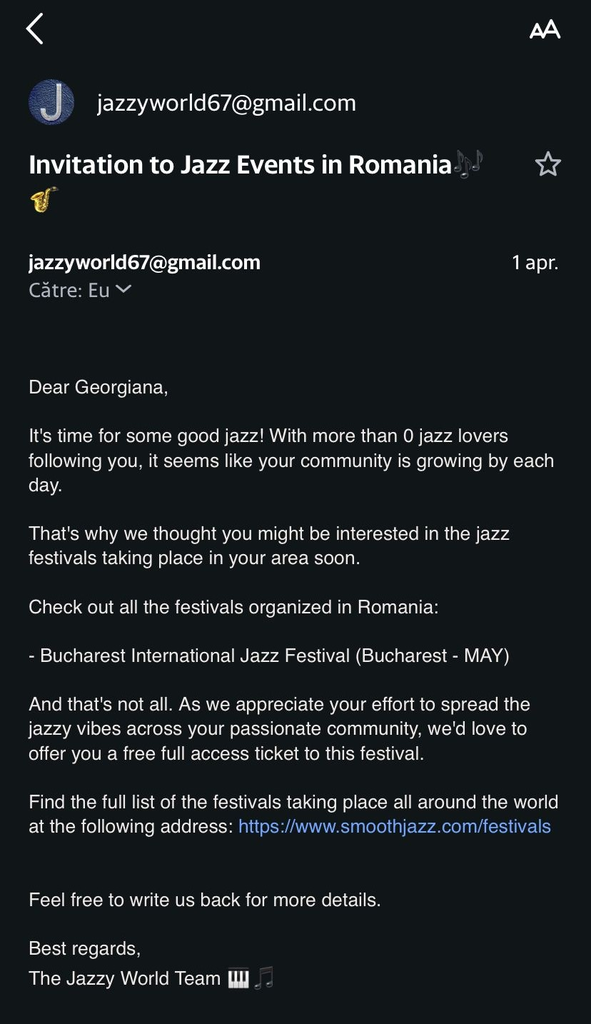

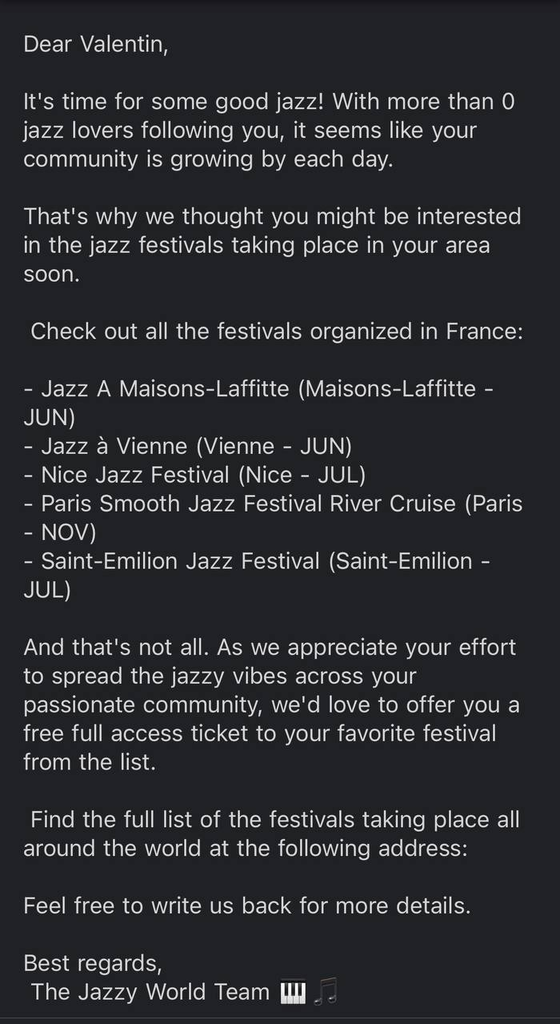

## 4. Fonctions qui appelle les fonctions de chaque partie et fonction globale get_everything()

```python
def get_bloggers(url):

    get_url(url)
    nom_blog = get_names(url) #nom des blogs
    localisation = get_locals(url) #localisation des blogeurs
    site_web = get_webs(url) #sites web des blogeurs

    # abonnés sur Twitter, Facebook et Instagram
    twitsub = get_followers(url, "fs-twitter")
    fbsub = get_followers(url, "fs-facebook")
    instasub = get_followers(url, "fs-instagram")

    # abonnés convertis en nombre
    fbsub_num = [convertir_en_nombre(abonne) for abonne in fbsub]
    twitsub_num = [convertir_en_nombre(abonne) for abonne in twitsub]
    instasub_num = [convertir_en_nombre(abonne) for abonne in instasub]

    adresses_email = create_email()  # création des adresses mail pour chaque blogueur
    return [nom_blog, localisation, site_web, fbsub_num, twitsub_num, instasub_num, adresses_email]

url = "https://music.feedspot.com/jazz_blogs/"
#get_bloggers(url)
```

```python
# Mettre les commandes permetant de générer le tableau contenant l'ensemble des données des bloguers à l'intérieur d'une fonction
def create_datablog():
    DataBlog = {"Nom Blog": nom_blog,
                "Pays": Pays,
                "Région": Region,
                "Ville": Ville,
                "Adresse Email": create_email(),
                "Site web": site_web,
                "Abonnées Facebook": fbsub_num,
                "Abonnées Twitter": twitsub_num,
                "Abonnées Instagram": instasub_num
                }

    TableBlog = pd.DataFrame(DataBlog)
    TableBlog["Pays"] = TableBlog["Pays"].replace({"US": "USA"})

    return TableBlog

# Créer le DataFrame initial
TableBlog = create_datablog()
```

```python
def get_festivals():
    get_all_pages() # récupérer toutes les pages du site
    get_event_names(url) #récuperer les noms des festivals
    TableEvent = scrape_all_events() #générer un tableau qui comporte les informations sur les festivals (nom, pays, période, ville etc.)
    TableEvent["Pays_Event"] = TableEvent["Pays_Event"].replace({"United States": "USA"}) #remplacer United States par USA
    print(TableEvent)

get_festivals()
```

[output not shown]

```python
# Créer la fonction finale qui permet d'appeller l'ensemble des fonctions créées précédemment et d'exécuter l'intégralité du code des trois parties
def get_everything():
    get_bloggers(url) #fonction qui appelle l'ensemble des fonctions du script des bloguers pour récuperer les données
    create_datablog() #fonction qui crée le tableau TableBlog
    get_festivals() #fonction qui appelle l'ensemble des fonctions du script des festivals pour récuperer les données
    format_blogger_email(blog['Nom Blog'], followers, country) #fonction qui permet de personnaliser le mail automatique
    format_event_list(country_events) #fonction qui permet de personnaliser le mail automatique
    send_jazz_event_invitations("smtp.gmail.com", 465, "jazzyworld67@gmail.com", "ogunqrpjhigzwpfc", TableBlog, TableEvent) #fonction qui assure la connexion au serveur SMTP, l'envoi du mail à l'ensemble des adresses et la déconnexion du serveurs

#get_everything()
```

Ce que nous avons appris grâce à notre projet de web scraping:

- Inspecter attentivement la structure des pages à scraper pour identifier certains patterns
- Utiliser des fonctions par blocs pour pouvoir relier les différentes parties
- Gérer les bases de données
- Créer et envoyer le mail automatique personnalisé
- Utilisation du serveur SMTP
- Répondre à des problématiques de marketing (segmentation) ## Extensions possibles:
- Ajouter un bouton intéractif dans le mail pour demander au destinataire s’il souhaite obtenir plus d’informations
- Rendre dynamique de sorte façon à signaler lorsqu’il y a de nouveaux festivals
- Inclure plus de sites pour tenir compte aussi de petits festivals locaux